# Visualizing the Model: Interactions

## Introduction

- In the previous weeks, we have built up what we understand about data visualization.
  - Week 1: Visualizing models with only continuous predictors
  - Week 2: Visualizing models with only categorical predictors; visualizing models with both continuous and categorical predictors
  - Week 3: Visualizing models with interaction terms.
- We have seen this week that there are three types of interactions:
  - Continuous $\times$ continuous
  - Categorical $\times$ categorical
  - Continuous $\times$ categorical
- Graphing a model with only categorical variables and interactions will follow what we learned for models with only categorical variables in Week 2.
- In this lecture we will focus on models with at least one continuous predictor in them.

## Lecture Example Set Up

- Recall the Clarabelle data,
- We have a dataset with 300 days of operation for:
  - Average wait time (*avg_wait_time*): Average customer wait time (in minutes) on a given day.
  - Orders per hour (*orders_per_hour*): Average number of milkshake orders per hour that day.
  - Staff experience (*staff_experience*): Average years of experience among staff working that shift.
  - Special flavor (*flavor_special*): Type of milkshake special offered that day (none, seasonal, or limited edition).
  - Status of milkshake machine (*machine_status*): Whether the milkshake machine was fully operational or temperamental that day.

```r
clarabelle <- read_csv("https://raw.githubusercontent.com/samanthaseals/SDSII/refs/heads/main/files/data/lectures/W3_clarabelle.csv")
```

## Example 1

- In the last lecture, we constructed the following model:

$$\hat{\text{wait time}} = 4.88 + 0.08 \text{ orders} + 2.88 \text{ temp.} + 0.06 \text{ orders $\times$ temp.}$$

$$\begin{align*}
\hat{\text{wait time}|\text{op.}} &= 4.88 + 0.08 \text{ orders} \\
\hat{\text{wait time}|\text{temp.}} &= 7.76 + 0.14 \text{ orders}
\end{align*}$$

- We will use the statified models for visualization.
  - We will have one regression line for when the machine is fully operational and another for when it is temperamental.

## Example 1

- First, we will find predicted values,

```r
clarabelle <- clarabelle %>%
  mutate(y_op = 4.88 + 0.08 * orders_per_hour,
         y_temp = 7.76 + 0.14 * orders_per_hour)
```

| orders_per_hour | machine_status | y_op | y_temp |
| --- | --- | --- | --- |
| 7.645707 | Temperamental | 5.491657 | 8.830399 |
| 24.174138 | Fully Operational | 6.813931 | 11.144379 |
| 24.802865 | Fully Operational | 6.864229 | 11.232401 |
| 11.827346 | Fully Operational | 5.826188 | 9.415828 |
| 26.913342 | Temperamental | 7.033067 | 11.527868 |
| 13.390703 | Fully Operational | 5.951256 | 9.634698 |

## Example 1

- Then, our code to graph,

```r
clarabelle %>% ggplot(aes(x = orders_per_hour)) +
  geom_point(aes(y = avg_wait_time, color = machine_status), alpha = 0.5) +
  geom_line(aes(y = y_op), color = "#F8766D", size = 1) +
  geom_line(aes(y = y_temp), color = "#00BFC4", size = 1) +
  labs(x = "Orders per Hour",
       y = "Average Wait Time (minutes)",
       color = "Machine Status") +
  theme_bw()
```

## Example 1

- Looking at our graph,

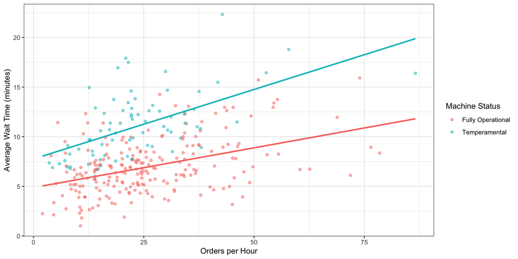

## Example 2

- We also constructed this model:

$$\begin{align*}
\hat{\text{wait time}} = 4.&90 \\
& + 0.08 \text{ orders} \\
& + 1.16 \text{ seasonal} + 3.95 \text{ limited edition} \\
& - 0.01 \text{ orders $\times$ seasonal} + 0.02 \text{ orders $\times$ limited edition}
\end{align*}$$

- Although the interaction was not significant $(p = 0.7206)$, we can still provide a data visualization of that specific model.
  - I will do this to demonstrate to others what I mean by “there is not an interaction”.

## Example 2

- Thus, our stratified models (see last lecture for derivation):,

$$\begin{align*}
\hat{\text{wait time}|\text{no special}} &= 4.90 + 0.08 \text{ orders} \\
\hat{\text{wait time}|\text{seasonal}} &= 6.06 + 0.07 \text{ orders} \\
\hat{\text{wait time}|\text{limited edition}} &= 8.85 + 0.10 \text{ orders}
\end{align*}$$

- We will have three lines on our graph: one for each type of special flavor offering.

## Example 2

- Finding predicted values,

```r
clarabelle <- clarabelle %>%
  mutate(y_none = 4.90 + 0.08 * orders_per_hour,
         y_seasonal = 6.06 + 0.07 * orders_per_hour,
         y_limited = 8.85 + 0.10 * orders_per_hour)
```

| orders_per_hour | flavor_special | y_none | y_seasonal | y_limited |
| --- | --- | --- | --- | --- |
| 7.645707 | Seasonal | 5.511657 | 6.595199 | 9.614571 |
| 24.174138 | None | 6.833931 | 7.752190 | 11.267414 |
| 24.802865 | None | 6.884229 | 7.796201 | 11.330286 |
| 11.827346 | Limited Edition | 5.846188 | 6.887914 | 10.032735 |
| 26.913342 | None | 7.053067 | 7.943934 | 11.541334 |
| 13.390703 | None | 5.971256 | 6.997349 | 10.189070 |

## Example 2

- Then, our code to graph,

```r
clarabelle %>% ggplot(aes(x = orders_per_hour)) +
  geom_point(aes(y = avg_wait_time, color = flavor_special), alpha = 0.5) +
  geom_line(aes(y = y_none), color = "#00BA38", size = 1) +
  geom_line(aes(y = y_seasonal), color = "#619CFF", size = 1) +
  geom_line(aes(y = y_limited), color = "#F8766D", size = 1) +
  labs(x = "Orders per Hour",
       y = "Average Wait Time (minutes)",
       color = "Flavor") +
  theme_bw()
```

## Example 2

- Looking at our graph,

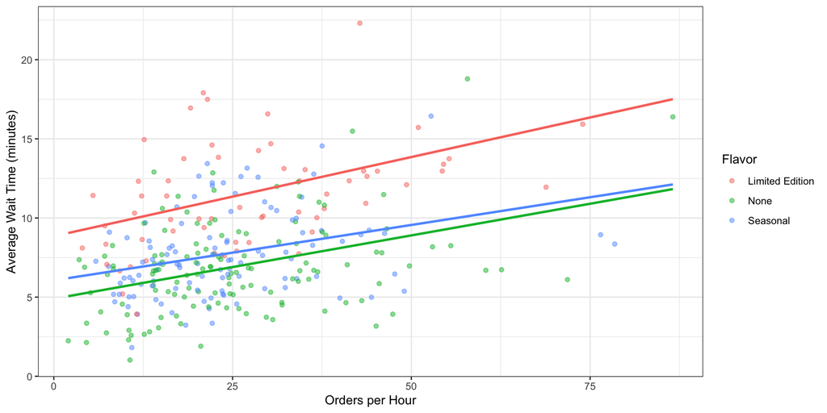

## Wrap Up

- This lecture has demonstrated how to visualize models with interaction terms.
- To keep it simple, we focused on models with at least one continuous predictor.
  - To deal with models with only categorical predictors (and interactions), please refer back to Week 2’s material.
- We now have the general building blocks for regression analysis.
  - After this week, we will leave the normal distribution, meant for continuous outcomes that are mound-shaped and symmetric, and begin exploring distributions for other types of outcomes.